## # Lab2 Answers File

## Please write your answers into the space below the questions. Knit this file when you are done to check that all code runs. Remember to rename the file to contain *your actual* Last and First name and **submit both the Rmd and Html file to canvas**.

#### Amatullah Mir

**1.1**

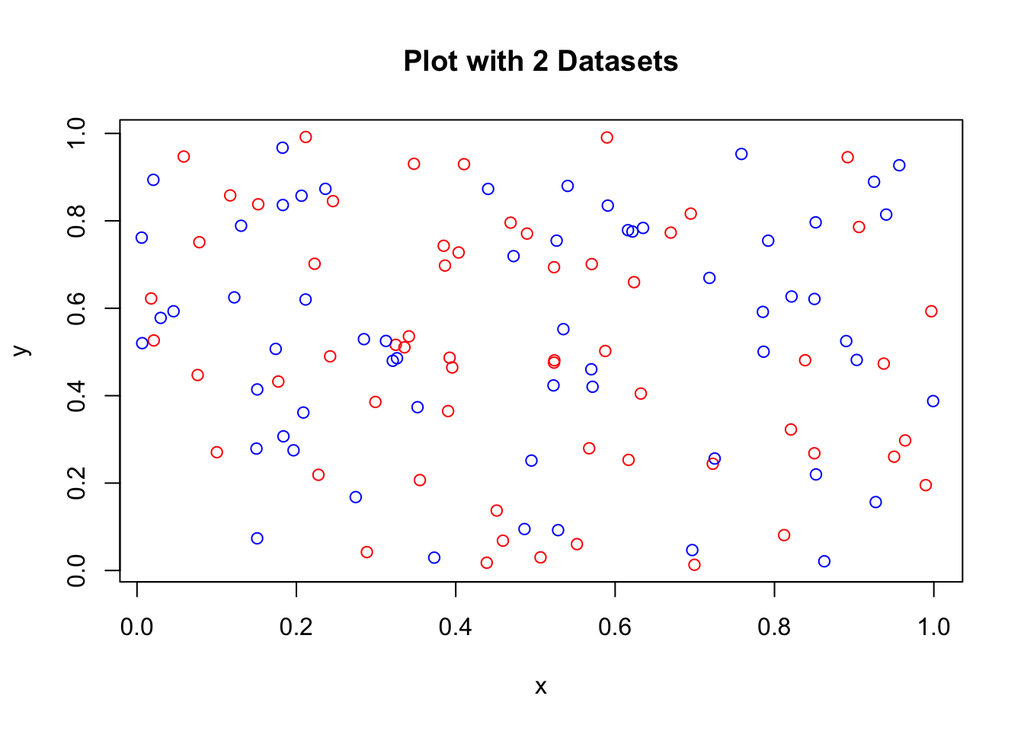

```r
x <- runif(60)
y <- runif(60)
x1 <- runif(60)
y1 <- runif(60)

plot(x, y, main = "Plot with 2 Datasets", col = "red")
points(x1, y1, col = "blue")
```

The data sets are both unique to one another, and appear scattered in the graph above.

**1.2**

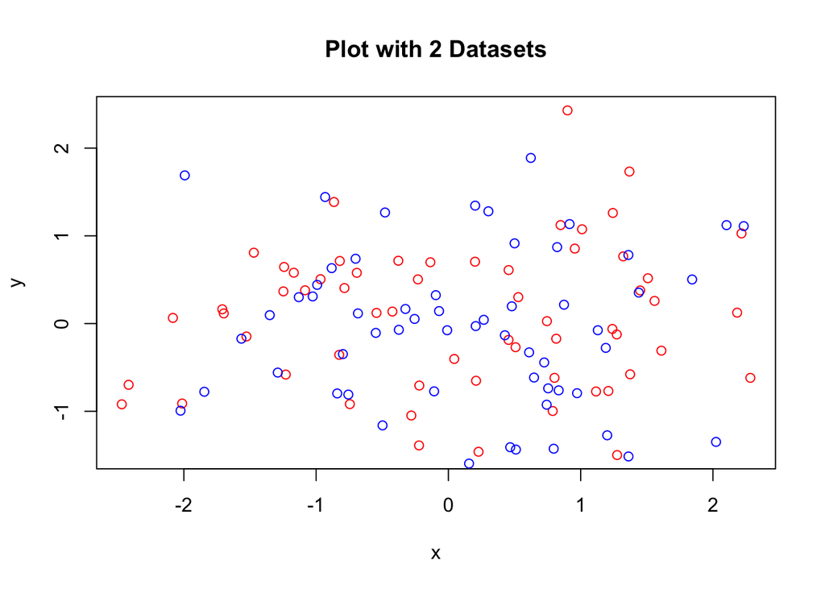

```r
x <- rnorm(60)
y <- rnorm(60)

x1 <- rnorm(60)
y1 <- rnorm(60)


plot(x, y, main = "Plot with 2 Datasets", col = "red")
points(x1, y1, col = "blue")
```

This plot shows normally distributed data points, with clustering towards the middle.

**1.3**

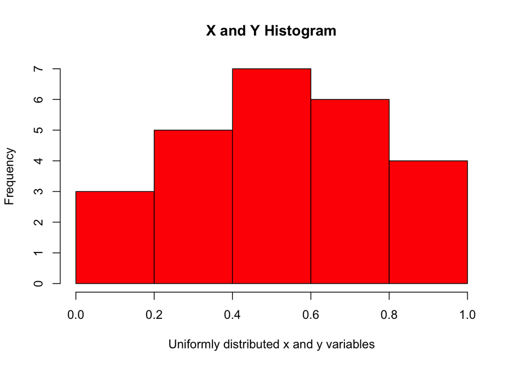

```r
a <- runif(25)
b <- runif(250)
c <- runif(2500)
d <- runif(2500000)


hist(a, xlab = "Uniformly distributed x and y variables", main = "X and Y Histogram", col = "red")
```

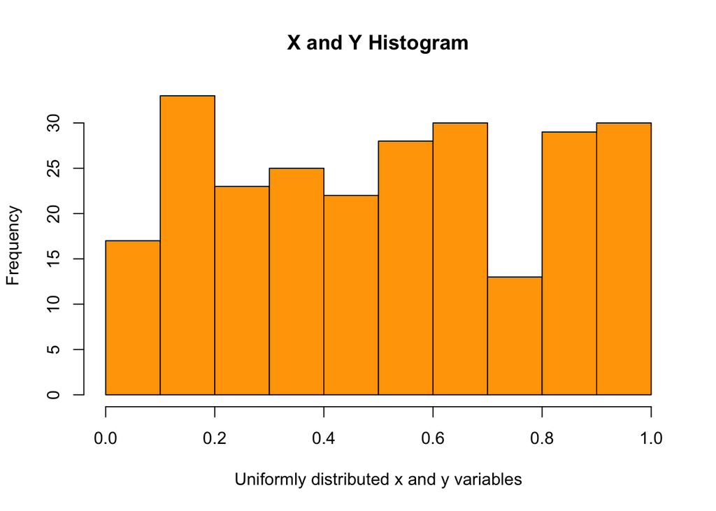

```r
hist(b, xlab = "Uniformly distributed x and y variables", main = "X and Y Histogram", col = "orange")
```

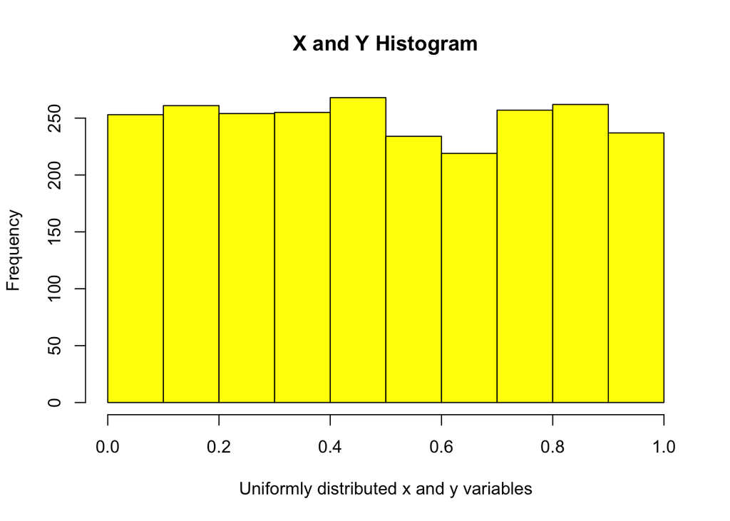

```r
hist(c, xlab = "Uniformly distributed x and y variables", main = "X and Y Histogram", col = "yellow")
```

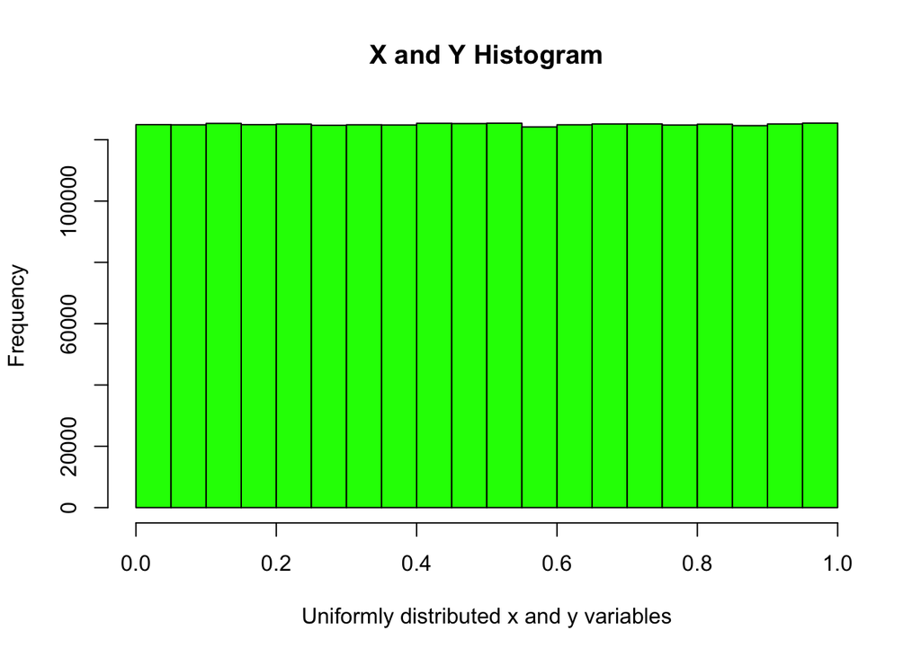

```r
hist(d, xlab = "Uniformly distributed x and y variables", main = "X and Y Histogram", col = "green")
```

As the numbers increase, the histograms appear increasingly uniform.

**1.4**

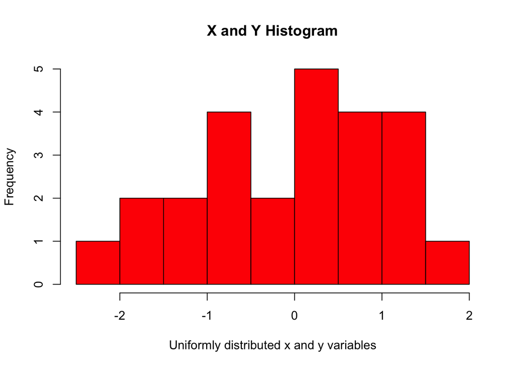

```r
a <- rnorm(25)
b <- rnorm(250)
c <- rnorm(2500)
d <- rnorm(2500000)


hist(a, xlab = "Uniformly distributed x and y variables", main = "X and Y Histogram", col = "red")
```

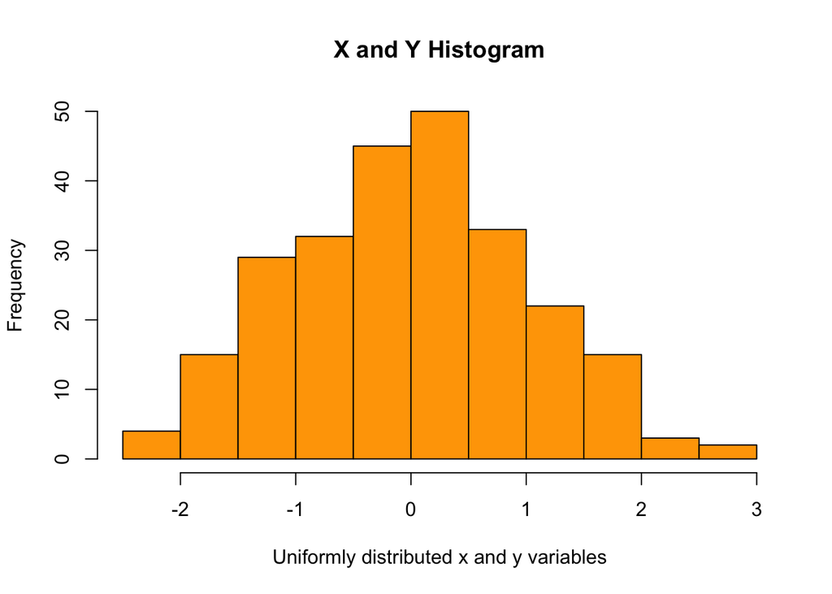

```r
hist(b, xlab = "Uniformly distributed x and y variables", main = "X and Y Histogram", col = "orange")
```

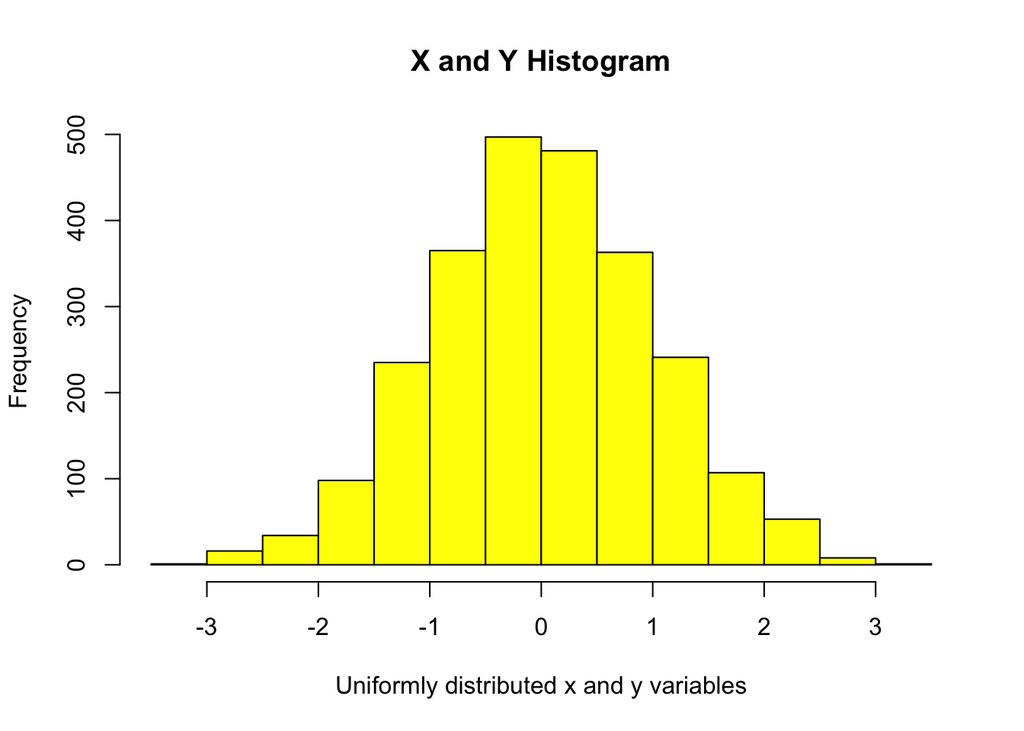

```r
hist(c, xlab = "Uniformly distributed x and y variables", main = "X and Y Histogram", col = "yellow")
```

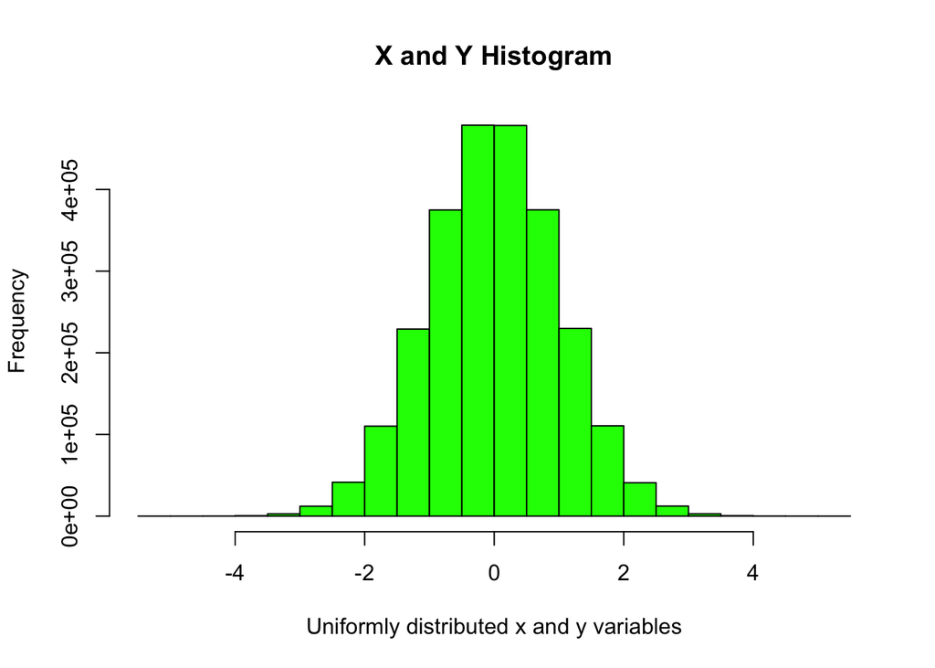

```r
hist(d, xlab = "Uniformly distributed x and y variables", main = "X and Y Histogram", col = "green")
```

**2.1**  
Adding more breaks, the data intervals become slightly smaller, giving the graph more shape and in some cases, more accuracy.

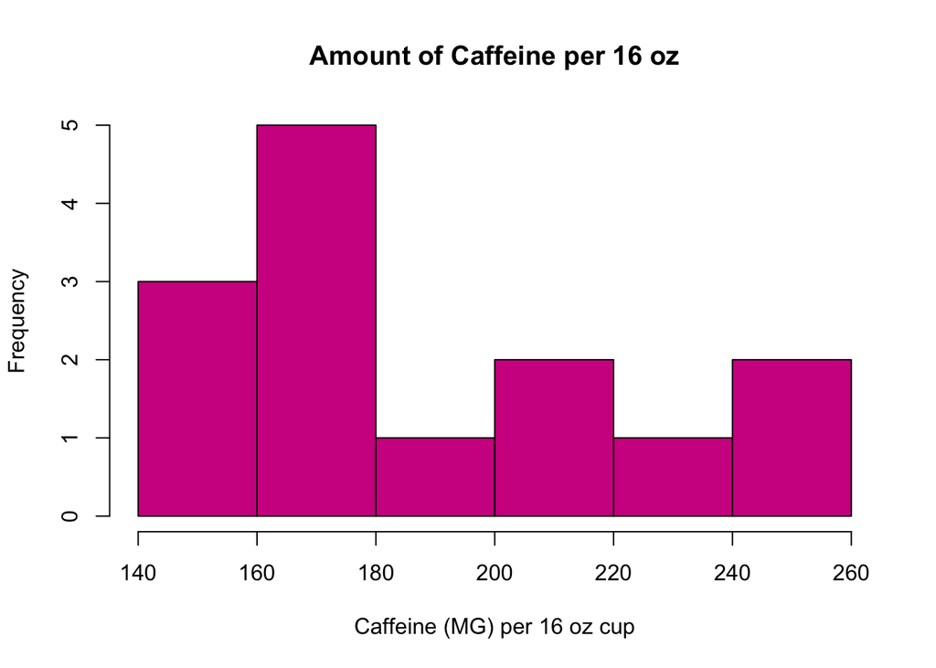

```r
hist(caffeine_Data$Caffeine_mg_in_16_oz_coffee, xlab = 'Caffeine (MG) per 16 oz cup', main = "Amount of Caffeine per 16 oz", col = 'violetred', breaks = 6)
```

**2.2**  
176528 Structures and 52105 Structures of Human Sequences.

**2.3**

```r
protein_Data <- read.csv("protein_data.csv", header = TRUE, stringsAsFactors = FALSE)
head(protein_Data)
```

```
##   protein.IDs length
## 1        2H0A    276
## 2        3MFX    387
## 3        1KQ6    141
## 4        4NWB    278
## 5        4XUU    676
## 6        3OQB   3064
```

```r
protein_Data$length
```

[output not shown]

[output cut: 757 more lines]

```r
protein_Data$length[1:20]
```

```
##  [1]  276  387  141  278  676 3064 1408  438  133  468   91 1248  789  215  777
## [16]  612 1238  329  150  392
```

```r
ncol(protein_Data)
```

```
## [1] 2
```

```r
nrow(protein_Data) # 10798
```

```
## [1] 10798
```

```r
colnames(protein_Data)
```

```
## [1] "protein.IDs" "length"
```

**2.4**

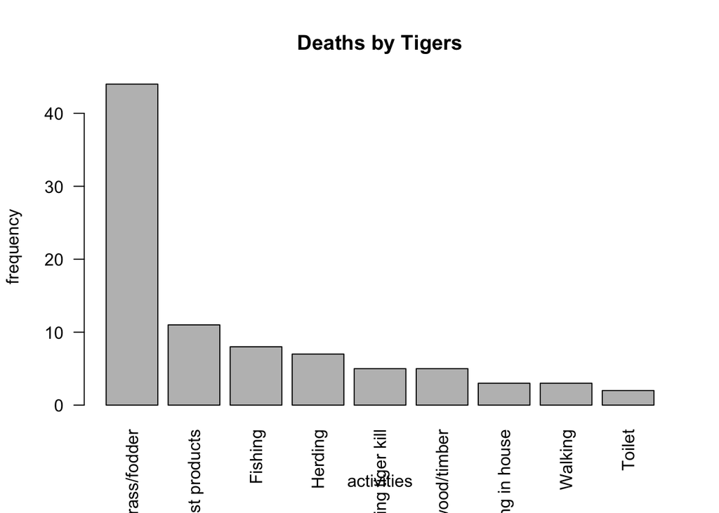

```r
dftigers <- read.csv('DeathsFromTigers.csv', header = TRUE, stringsAsFactors = FALSE)
tiger_Table <- sort(table(dftigers$activity), decreasing=T)

barplot(tiger_Table, xlab = "activities", ylab = "frequency", main = "Deaths by Tigers", las = 2)
```

**2.5 (a)**

```r
dfmeasles <- read.csv('MeaslesOutbreaks.csv', header = TRUE, stringsAsFactors = FALSE)
```

**(b)**

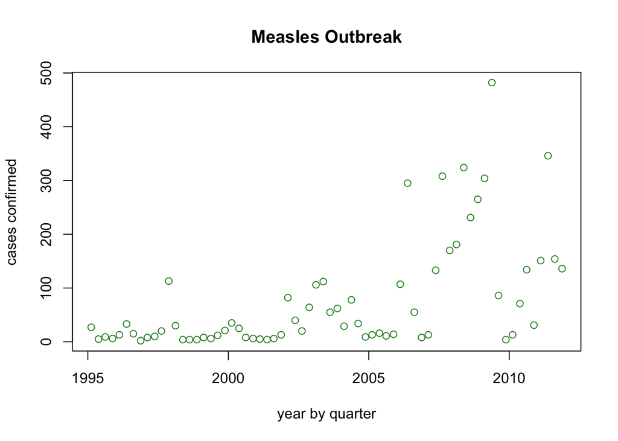

```r
plot(dfmeasles$yearByQuarter, dfmeasles$confirmedCases, main = "Measles Outbreak", xlab = "year by quarter", ylab = "cases confirmed", col = "forestgreen")
```

**(c)**

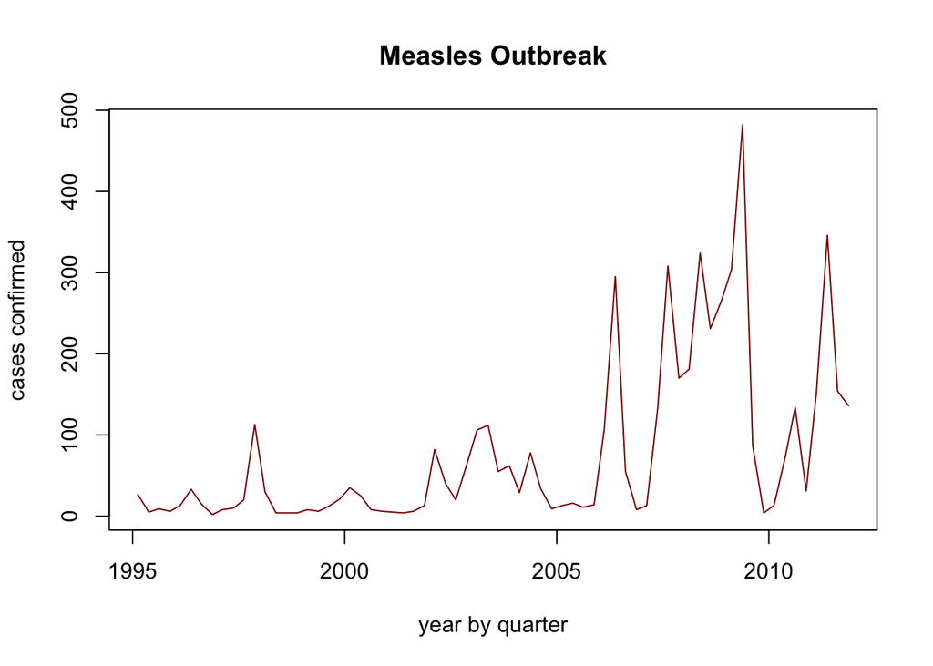

```r
plot(dfmeasles$yearByQuarter, dfmeasles$confirmedCases, main = "Measles Outbreak", xlab = "year by quarter", ylab = "cases confirmed", col = "dark red", type = "l")
```

**2.6 (a)**

```r
dfcountries <- read.csv('countries2005.csv', header = TRUE, stringsAsFactors = FALSE)
```

**(b)**

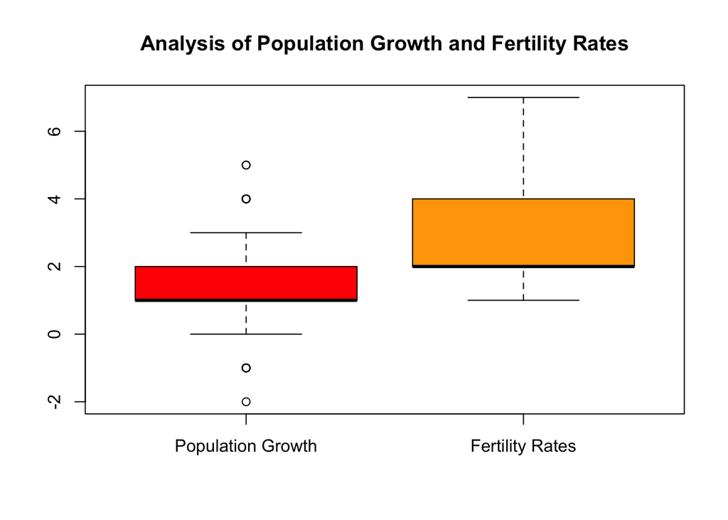

```r
boxplot(dfcountries$Population_growth, dfcountries$Fertility_rate, main = "Analysis of Population Growth and Fertility Rates", names = c("Population Growth", "Fertility Rates"), col = c("red", "orange"))
```

```r
# the categorical variables are the countries and continents on the excel sheet, and every variable on the file are all numerical. The explanatory variables are population growth and fertility rates, and the response variable are the numbers of population growth and ferility rates calculated.
```

**(c)**

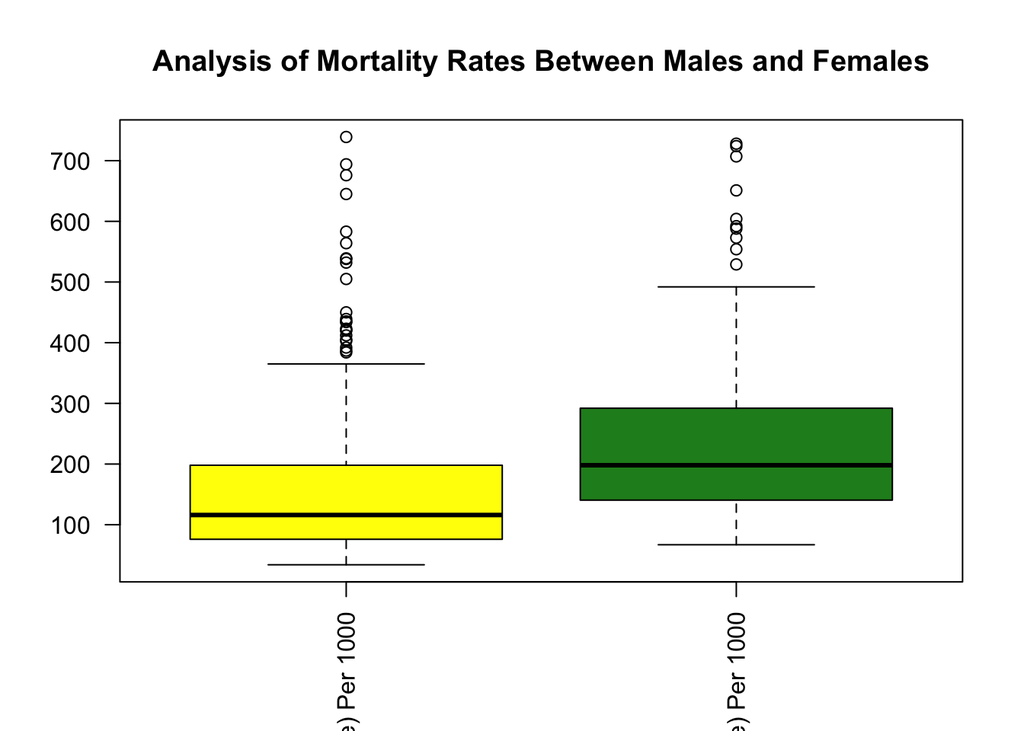

```r
boxplot(dfcountries$Mortality_rate_adult_female_per_1000, dfcountries$Mortality_rate_adult_male_per_1000, main = "Analysis of Mortality Rates Between Males and Females", names = c("Mortality Rates (Adult Female) Per 1000", "Mortality Rates (Adult Male) Per 1000"), col = c("yellow", "forest green"), las = 2)
```

```r
# The median for mortality rates is higher for adult men than for adult women. The overall box plots show that mortality rates for men are higher than mortality rates for women.
```

**3.1**

```r
quad <- function(num){
  return(num^4)
}

quad(34)
```

```
## [1] 1336336
```

**3.2**

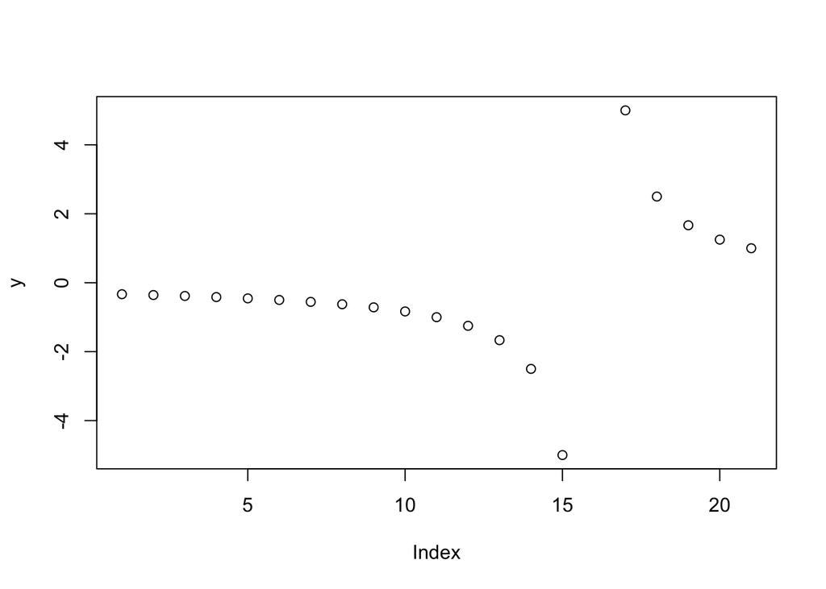

```r
fiverecip <- function(vec){
  y <- (1/vec)*5
  plot(y)
}

fiverecip(-15:5)
```

**3.3**

```r
my_Range <- function(vec){
  return(c(min(vec), max(vec)))
}

my_Range(c(6,18,3,9,24,12))
```

```
## [1]  3 24
```

**3.4**

```r
my_Mean <- function(vec){
  return(sum(vec)/length(vec))
}

vec1 <- c(6,18,3,9,24,12)
my_Mean(vec1)
```

```
## [1] 12
```

```r
mean(vec1)
```

```
## [1] 12
```

**3.5 (a)**

```r
mySD <-function(input)
  return(sqrt(sum(
    ((input)-(my_Mean(input)))^2)/(length(input)-1)))

vec1 <- seq(1, 100, 0.5)
mySD(vec1)
```

```
## [1] 28.79525
```

```r
sd(vec1)
```

```
## [1] 28.79525
```

**(b)**

```r
if(mySD(vec1) == sd(vec1)){
  print("Your code is correct")
} else {
  print("Try again!")
}
```

```
## [1] "Your code is correct"
```

**3.6 (a)**

```r
library('seqinr')
dengue <- read.fasta(file = 'dengue_seq.txt')
dengue_vec <- as.vector(dengue[[1]])

GC_content <- function(seq){
  length <- 0
  c <- 0
  g <- 0

for(i in dengue_vec){
  length <- length + 1
  if(i=="c"){
    c <- c+1
  }
  if(i=="g"){
    g <- g+1
  }
}
  GC_content <- ((g+c)/length)*100
  return(GC_content)
}
```

**(b)**

```r
GC_content(dengue_vec)
```

```
## [1] 46.66977
```

**3.7 (a)**

```r
corona <- read.csv('coronadata.csv', header = TRUE, stringsAsFactors = FALSE)
```

**(b)**

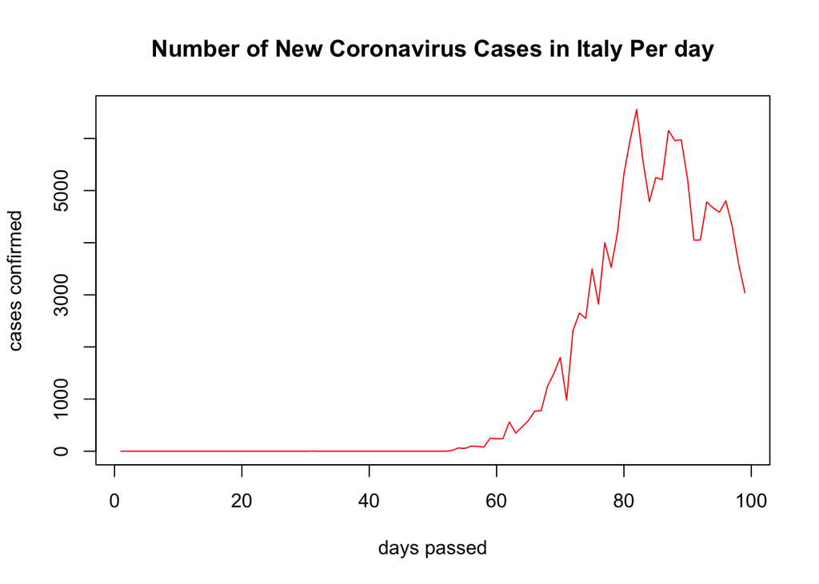

```r
plot(corona$Day, corona$Italy, main = "Number of New Coronavirus Cases in Italy Per day", xlab = "days passed", ylab = "cases confirmed", col = "red", type = "l")
```

**(c)**

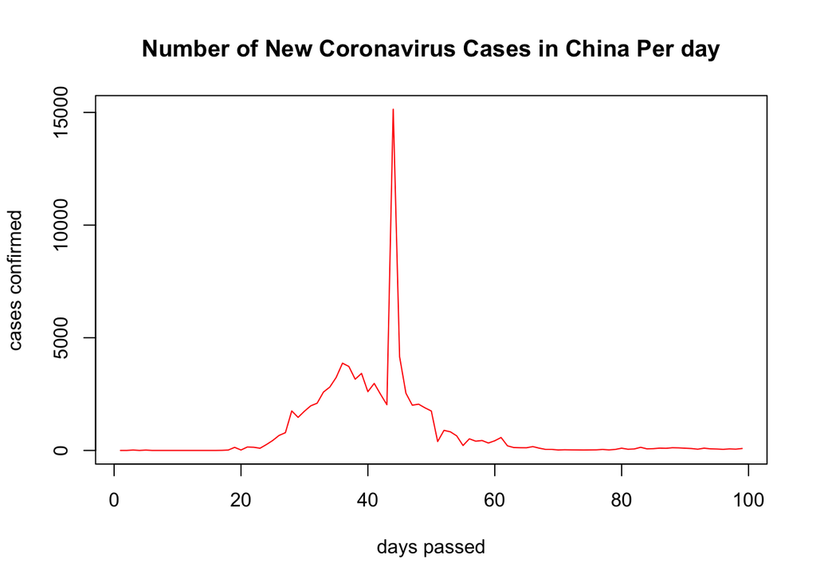

```r
plot(corona$Day, corona$China, main = "Number of New Coronavirus Cases in China Per day", xlab = "days passed", ylab = "cases confirmed", col = "red", type = "l")
```

**(d)**

```r
# The cases in China spiked sooner and reached extremely high levels towards 40-50 days. As for Italy, their cases did not peak until after 60 days. The graph for Italy appears left skewed and the graph for China does not seem to have a skew.
```